# Lab 3

October 16th 2017

## Normal Model

## Why Be Normal?

- often the posterior is known to be unimodal and symmetric
- we can effectively model it with a normal distribution even if we know that the form is only nearly normal
- in cases where the researcher has a rough idea of where an unknown parameter is centered, the normal provides a useful way of modeling this guess that allow the level of uncertainty to be described by the normal variance term

## Why Be Normal?

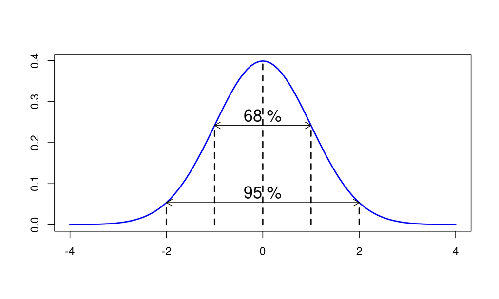

\(\mathcal{N}(\mu, \sigma^2) = (2\pi\sigma^2)^{-\frac{1}{2}}\ exp[-\frac{1}{2\sigma^2}(X - \mu)^2]\)

## Normal Model with Variance Known

Likelihood

\(X|\mu, \sigma_0^2 \sim \mathcal{N}(\mu, \sigma_0^2) = (2\pi\sigma_0^2)^{-\frac{1}{2}}\ exp[-\frac{1}{2\sigma_0^2}(X - \mu)^2]\)

Prior

\(\mu|m, s^2 \sim \mathcal{N}(m, s^2) = (2\pi s^2)^{-\frac{1}{2}}\ exp[-\frac{1}{2s^2}(\mu - m)^2]\)

## Normal Model with Variance Known

Posterior

\(p(\mathrm{x}|\mu)p(\mu) \propto exp[-\frac{1}{2}(\frac{1}{\sigma_0^2}\sum_{i=1}^n(x_i - \mu)^2 + \frac{1}{s^2}(\mu - m)^2)]\)

\(\propto exp \left[-\frac{1}{2} \left(\frac{1}{s^2} + \frac{n}{\sigma_0^2} \right) \left(\mu - \frac{\left(\frac{m}{s^2} + \frac{n\bar{x}}{\sigma_0^2} \right)}{\left(\frac{1}{s^2} + \frac{n}{\sigma_0^2} \right)} \right)^2 \right]\)

## Normal Model with Variance Known

Posterior mean is:

\(\hat{\mu} = \left(\frac{m}{s^2} + \frac{n\bar{x}}{\sigma_0^2} \right) / \left(\frac{1}{s^2} + \frac{n}{\sigma_0^2} \right)\)

Posterior variance is:

\(\hat{\sigma_{\mu}^2} = \left(\frac{1}{s^2} + \frac{n}{\sigma_0^2} \right)^{-1} = \frac{s^2 \sigma_0^2}{\sigma_0^2 + ns^2}\)

## Plethora of Priors

## Conjugate priors

- In most of our examples we were using a special type of prior distribution, so called conjugate priors.
- They have a very special feature: if you multiply likelihood times conjugate prior, you will obtain posterior of the same form as prior
- *Examples*:
- Beta prior x binomial likelihood = Beta posterior
- Normal prior x normal likelihood (mean) = Normal posterior
- Gamma prior x normal likelihood (variance) = Gamma posterior
- There are many others, but from my experience, these are three most often used in analyses of psychological data

## Uninformative (reference) priors

- Sometimes when we don't have any prior beliefs regarding the values of the parameters we can use so callled uninformative prior
- Sometimes it is called reference prior or weakly informative prior
- The general idea is to use prior that assigns 'equal' probabilities to all values of the parameters
- If we use uninformative prior we will usually get conclusions similar to the classical (frequentist) approach

## Informative Priors

- previous studies, published work
- researcher intuition
- interviewing substantive experts
- convenience through conjugacy
- nonparametrics and other data derived sources

## Community of Elicited Priors

- **clinical priors** - substantive experts who are taking part in the research project (easily captured)
- **skeptical priors** - built with the assumption that the hypothesized effect does not actually exist; overcoming such a prior provides stronger evidence
- **enthusiastic priors** - opposite of the skeptical priors, assume the existence of the hypothesized effect
- **reference priors** - they are used as a standard way to deal with some problem, uninformative, 'nonsubjective', occasionally produced by experts but not truely elicited

## V-method

- An expert is asked: what would be an expected value low value as a 0.25 quantile (labeled \(x_{0.25}\)) and an expected high value as a 0.75 quantile (labeled \(x_{0.75}\)).
- These two supplied values, \(x_{0.25}\) and \(x_{0.75}\), correspond to normal z-scores \(z_{0.25}\) = -0.6745 and \(z_{0.75}\) = 0.6745, which specify the shape of a normal PDF since there are two equations and two unknowns:

\(z_{0.25} = \frac{x_{0.25} - \alpha}{\beta}\) \(z_{0.75} = \frac{x_{0.75} - \alpha}{\beta}\)

- Here \(\alpha\) and \(\beta\) are the mean and standard deviation parameters of the normal PDF

## Elicitation using linear regression

- of course one expert is typically not enough to produce robust prior forms, we can query *J* experts
- this produces \(J \times 2\) equations and only two unknowns
- we can also ask each expert for more than just two quantiles
- e.g. each assessor is asked to give values at m = [0.1, 0.25, 0.5, 0.75, 0.99] corresponding to standard normal points \(z_m\)
- at this point we can re-express previous equations for the quartile level *m* given by assessor *j*: \(x_{jm} = \alpha + \beta z_{jm}\)
- and run a simple linear regression to estimate \(\alpha\) as the intercept and \(\beta\) as the slope